# 304726322_stats102a_hw1

Nicholas Barad

1/21/2020

```r
source("304726322_stats102A_hw1.R")
```

## Question 1: Greatest Common Divisor (GCD)

gcd() finds the GCD of two numbers

```r
gcd(462,1071)
```

```
## [1] 21
```

```r
gcd(1406,646)
```

```
## [1] 38
```

```r
gcd(100,3)
```

```
## [1] 1
```

```r
gcd(180,25)
```

```
## [1] 5
```

A flowchart of this function can be found below. The source code is found in a seperate .R file.

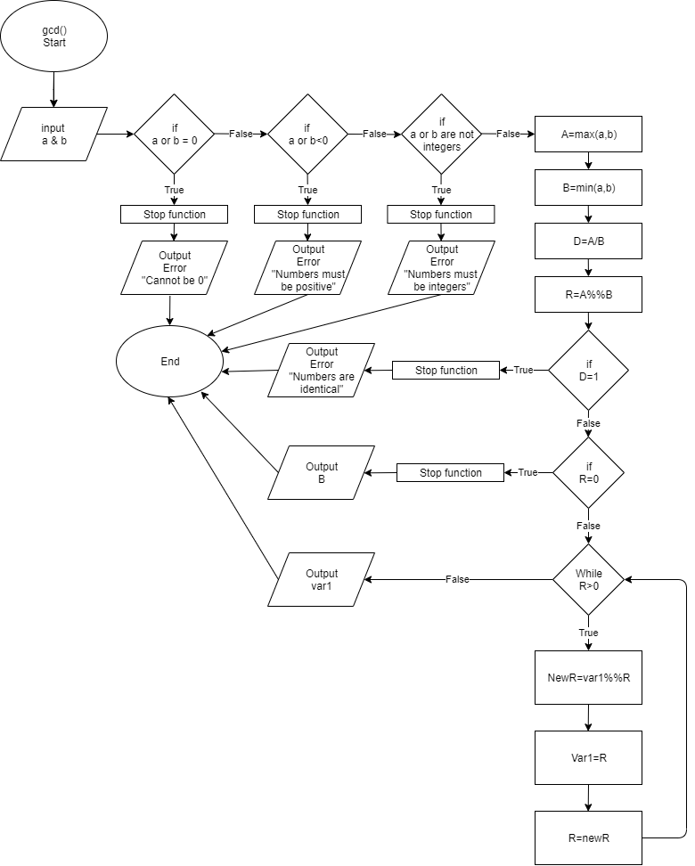

```r
knitr::include_graphics("gcd_nb.png")
```

Error handeling for gcd() is shown below

```r
try(gcd(0,10))
```

```
## [1] "Cannot use 0"
## Error in gcd(0, 10) : Cannot use 0
```

```r
try(gcd(10,10))
```

```
## [1] "Numbers are identical"
## Error in gcd(10, 10) : Numbers are identical
```

```r
try(gcd(-10,100))
```

```
## [1] "Numbers must be positive"
## Error in gcd(-10, 100) : Numbers must be positive
```

```r
try(gcd(10.5,100))
```

```
## [1] "Numbers must be integers"
## Error in gcd(10.5, 100) : Numbers must be integers
```

gcd_three() finds the GCD of three numbers

```r
gcd_three(1071, 462, 4452)
```

```
## [1] 21
```

```r
gcd_three(1000,3,9)
```

```
## [1] 1
```

A flowchart of this function can be found below. The source code is found in a seperate .R file.

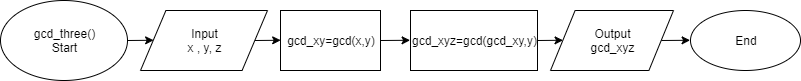

```r
knitr::include_graphics("gcd_three_NB.png")
```

Error handeling for gcd_three() is shown below

```r
try(gcd_three(0,10,15))
```

```
## [1] "Cannot use 0"
## Error in gcd(x, y) : Cannot use 0
```

```r
try(gcd_three(10,10,15))
```

```
## [1] "Numbers are identical"
## Error in gcd(x, y) : Numbers are identical
```

```r
try(gcd_three(-10,100,1000))
```

```
## [1] "Numbers must be positive"
## Error in gcd(x, y) : Numbers must be positive
```

```r
try(gcd_three(10,10.5,100))
```

```
## [1] "Numbers must be integers"
## Error in gcd(x, y) : Numbers must be integers
```

## Question 2: Prime Factorization

get_factors() takes a value x and finds the prime factorization

```r
get_factors(7)
```

```
## [1] 7
```

```r
get_factors(10)
```

```
## [1] 2 5
```

```r
get_factors(200)
```

```
## [1] 2 2 2 5 5
```

```r
get_factors(32851)
```

```
## [1]  7 13 19 19
```

A flowchart of this function can be found below. The source code is found in a seperate .R file.

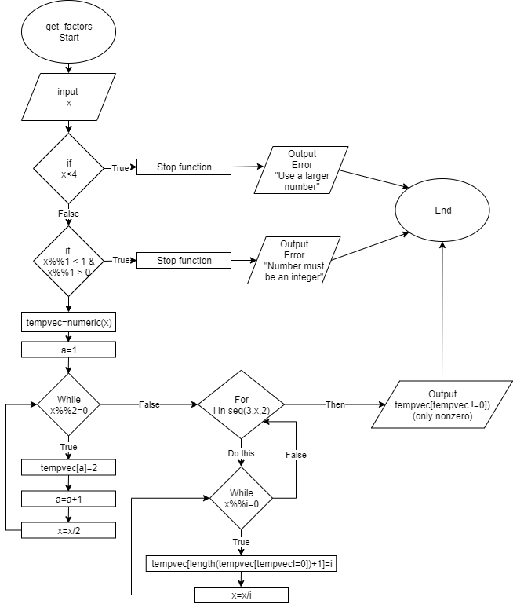

```r
knitr::include_graphics("get_factors_NB.png")
```

Error handeling for get_factors() is shown below. An input must be > 3 since 1,2,3 are all primes.

```r
try(get_factors(-10))
```

```
## [1] "Use a larger number"
## Error in get_factors(-10) : Use a larger number
```

```r
try(get_factors(3))
```

```
## [1] "Use a larger number"
## Error in get_factors(3) : Use a larger number
```

```r
try(get_factors(10.5))
```

```
## [1] "Number must be an integer"
## Error in get_factors(10.5) : Number must be an integer
```

These numbers can be verified as primes using a function is_prime

```r
is_prime(c(2,3,4,5,6,7))
```

```
## [1]  TRUE  TRUE FALSE  TRUE FALSE  TRUE
```

A flowchart of this function can be found below. The source code is found in a seperate .R file.

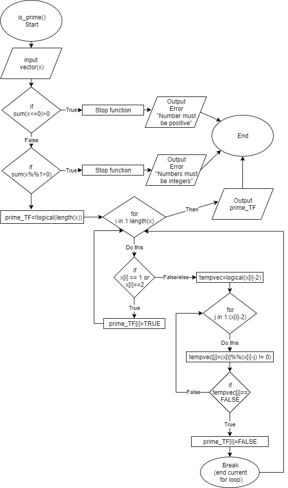

```r
knitr::include_graphics("is_prime_NB3.png")
```

is_prime() has valid error handeling as shown here

```r
try(is_prime(-5))
```

```
## [1] "Number must be positive"
## Error in is_prime(-5) : Number must be positive
```

```r
try(is_prime(5.5))
```

```
## [1] "Numbers must be integers"
## Error in is_prime(5.5) : Numbers must be integers
```

```r
try(is_prime(0))
```

```
## [1] "Number must be positive"
## Error in is_prime(0) : Number must be positive
```

The following test is used to verify get_factors() outputs are prime

```r
x <- sample(x = 1e4, size = 1)
y <- get_factors(x)
this_works <- prod(y) == x & all(is_prime(y))
this_works
```

```
## [1] TRUE
```